# Kim_Project_01

Joey

2024-10-07

## Introduction

An analysis of IQ levels by location status. The graph below shows the distribution of IQ levels by different location statuses. A summary table provides the means for each location status, and calculations are presented inline within the text at the result.

## Data

```r
# Load the dataset into a dataframe 'df' from the raw CSV file
df <- read.csv("C:/Users/Joey/iCloudDrive/Colorado-Biostatistics/2024-Fall/BIOS_6621_statistical consulting/BIOS6621_Projects/Kim_Project_01/DataRaw/lead-iq-01.csv")
head(df)
```

```
##   Smelter IQ
## 1     Far 70
## 2     Far 85
## 3     Far 86
## 4     Far 76
## 5     Far 96
## 6     Far 94
```

## Data Cleaning (Outlier)

```r
# Display the row with the incorrect value (IQ == 999)
df[df$IQ == 999, ]
```

```
##    Smelter  IQ
## 10     Far 999
```

```r
# Correct the outlier value from 999 to 99
df$IQ[df$IQ == 999] <- 99

# Verify the correction
df[df$IQ == 99, ]
```

```
##    Smelter IQ
## 10     Far 99
## 17     Far 99
## 20     Far 99
## 80    Near 99
```

Upon reviewing the dataset with PI, an odd IQ value of 999 was noticed, which seems highly improbable. After a discussion with the primary investigator, it was confirmed that this value should actually be 99.

## Graph (Bar Chart and Box Plot)

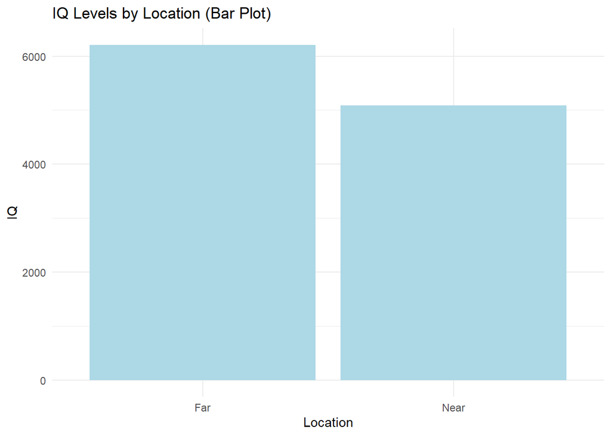

```r
# Load library for graph.
library(ggplot2)

# Create a Bar plot showing IQ levels by Smelter
ggplot(df, aes(x = Smelter, y = IQ)) +
  geom_bar(stat="identity", fill="light blue") +
  theme_minimal() +
  labs(title = "IQ Levels by Location (Bar Plot)", x = "Location", y = "IQ")
```

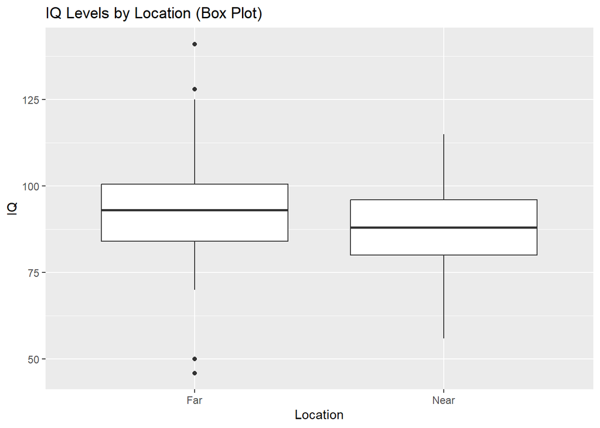

```r
# Create a Box plot showing IQ levels by Smelter
ggplot(df, aes(x = Smelter, y = IQ)) +
  geom_boxplot() +
  labs(title = "IQ Levels by Location (Box Plot)", x = "Location", y = "IQ")
```

The graph above presents the distribution of IQ levels across different location statuses: houses are located far or near from Smelter. The plot provides a visual summary of the spread of IQ scores within each location group. It allows for easy comparison of IQ distributions between different locations.

## Table

```r
# Load libraries to group the data by location and calculate descriptive statistics
library(dplyr)
# Create a summary table of mean, sd, min, max IQ by location
df_summary <- df %>%
  group_by(Smelter) %>%
  summarise(Mean_IQ = mean(IQ),
          SD_IQ = round(sd(IQ), 2),
          Min_IQ = min(IQ),
          Max_IQ = max(IQ),
          Count = n()
  )

# Load the knitr library to format the table
library(knitr)

# Display the summary table using kable from knitr, with a caption
kable(df_summary, caption = "Descriptive Statistics IQ Summary by Location")
```

Descriptive Statistics IQ Summary by Location

| Smelter | Mean_IQ | SD_IQ | Min_IQ | Max_IQ | Count |
| --- | --- | --- | --- | --- | --- |
| Far | 92.68657 | 15.97 | 46 | 141 | 67 |
| Near | 89.19298 | 12.17 | 56 | 115 | 57 |

The table summarizes key descriptive statistics for IQ by location status. It shows the mean, standard deviation, minimum, and maximum IQ values for individuals located near and far from the smelter. Notably, the ‘Far’ group has a higher average IQ but also includes significant variability, as highlighted by a potential outliers.

## Results

Mean IQ by Smelter Group

The mean IQ for individuals in the **Far** group is 92.69.

The mean IQ for individuals in the **Near** group is 89.19.